# Project 2: Data Mining, Classification, Prediction

### Dimensionality Reduction with PCA

```r
df_nums <- df %>% select_if(is.numeric) %>% scale
rownames(df_nums) <- df$player_name
df_nums <- as.data.frame(df_nums)
df_nums <- df_nums %>% select(c(-1, -2, -3, -4))  #remove extraneous data

df_pca <- princomp(df_nums, cor = T)

eigval <- df_pca$sdev^2  #square to convert SDs to eigenvalues
varprop = round(eigval/sum(eigval), 2)  #proportion of var explained by each PC

round(cumsum(eigval)/sum(eigval), 2)
```

```
##  Comp.1  Comp.2  Comp.3  Comp.4  Comp.5  Comp.6  Comp.7  Comp.8  Comp.9 Comp.10
##    0.59    0.77    0.84    0.90    0.94    0.97    0.99    1.00    1.00    1.00
## Comp.11 Comp.12 Comp.13 Comp.14 Comp.15 Comp.16
##    1.00    1.00    1.00    1.00    1.00    1.00
```

```r
# I will be keeping the first 3 comparisons
summary(df_pca, loadings = T)
```

```
## Importance of components:
##                           Comp.1    Comp.2    Comp.3     Comp.4     Comp.5
## Standard deviation     3.0804213 1.6832206 1.0694155 0.92451130 0.84537480
## Proportion of Variance 0.5930622 0.1770770 0.0714781 0.05342007 0.04466616
## Cumulative Proportion  0.5930622 0.7701392 0.8416173 0.89503737 0.93970353
##                            Comp.6     Comp.7      Comp.8      Comp.9
## Standard deviation     0.75051145 0.51658989 0.306638484 0.199906355
## Proportion of Variance 0.03520421 0.01667907 0.005876698 0.002497659
## Cumulative Proportion  0.97490774 0.99158681 0.997463507 0.999961167
##                             Comp.10      Comp.11      Comp.12      Comp.13
## Standard deviation     2.280541e-02 0.0100621268 2.016685e-08 1.978762e-08
## Proportion of Variance 3.250542e-05 0.0000063279 2.541886e-17 2.447186e-17
## Cumulative Proportion  9.999937e-01 1.0000000000 1.000000e+00 1.000000e+00
##                             Comp.14 Comp.15 Comp.16
## Standard deviation     1.867999e-08       0       0
## Proportion of Variance 2.180888e-17       0       0
## Cumulative Proportion  1.000000e+00       1       1
##
## Loadings:
##                      Comp.1 Comp.2 Comp.3 Comp.4 Comp.5 Comp.6 Comp.7 Comp.8
## raptor_box_offense    0.243  0.333  0.134  0.114  0.205  0.303  0.167
## raptor_box_defense    0.210 -0.415         0.241        -0.190         0.275
## raptor_box_total      0.307         0.154  0.237  0.119         0.170  0.250
## raptor_onoff_offense  0.229  0.210  0.120 -0.358        -0.662
## raptor_onoff_defense  0.155 -0.331 -0.173 -0.534  0.202  0.523
## raptor_onoff_total    0.265               -0.597        -0.159
##                      Comp.9 Comp.10 Comp.11 Comp.12 Comp.13 Comp.14 Comp.15
## raptor_box_offense    0.296  0.303   0.443
## raptor_box_defense   -0.244  0.338  -0.446
## raptor_box_total             0.432
## raptor_onoff_offense         0.108   0.143   0.105  -0.414   0.310
## raptor_onoff_defense         0.100  -0.142          -0.352   0.264
## raptor_onoff_total           0.142          -0.143   0.563  -0.422
##                      Comp.16
## raptor_box_offense    0.502
## raptor_box_defense    0.474
## raptor_box_total     -0.723
## raptor_onoff_offense
## raptor_onoff_defense
## raptor_onoff_total
##  [ reached getOption("max.print") -- omitted 10 rows ]
```

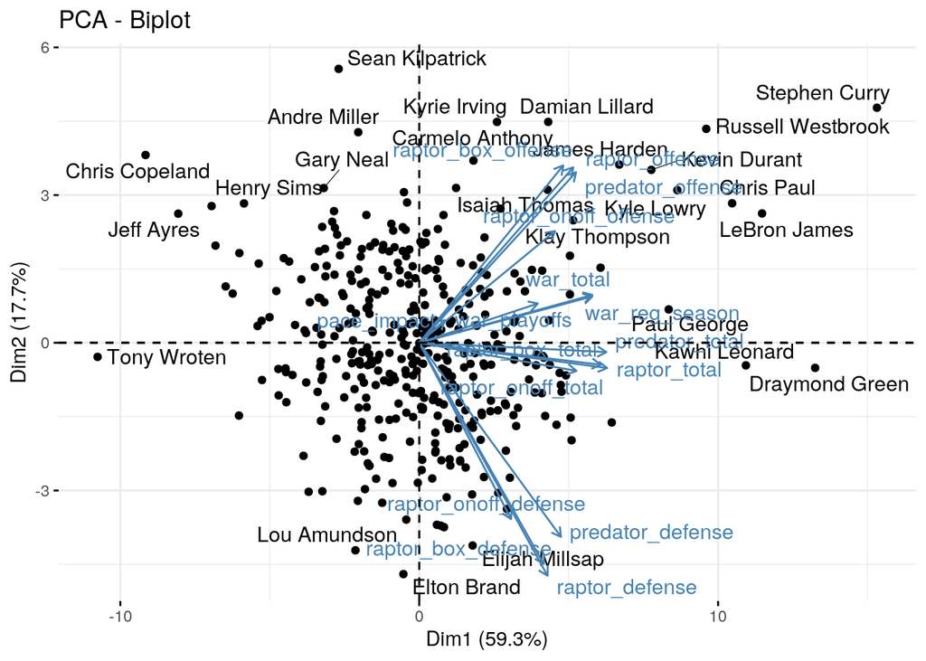

```r
library(factoextra)
fviz_pca_biplot(df_pca, repel = T)
```

The bi-plot is scatter plot of the placement of the different players along the first two comparison groups. This plot can be understood as those players who go nearly vertically down being better at defense while those in the top right quadrant are overall better at offense. I did identified some outliers, Draymond Green, Stephen curry , and Elton Brand. Draymond green was incredible on defense (6 RAPTOR), while being great at offense (8 RAPTOR) as well. Stephen curry had the best offensive season (10 RAPTOR) ever hence why he is in a league of his own in the top right quadrant. Elton brand was terrible on offense (-4 RAPTOR), while being amazing on defense (5 RAPTOR) showing why he goes straight vertically down.